# Comparing Bayesian and Frequentist Approaches in Estimating Population Mean from Sample Mean: A Dice-Rolling Experiment

Heinrich Hattingh, Arnab Kundu

2024-12-06

# Introduction

## Research Hypothesis

In a die-rolling experiment with $n$ samples of 3-sided or 6-sided dice, where $n \in \mathbb{N}$, the sample mean will provide a more accurate estimation of the population mean using Bayesian inference compared to the Central Limit Theorem. This will be investigated through finding and comparing estimations for the true mean of a dice.

## Background

When you roll a die multiple times, sum the outcomes, and then divide by the number of rolls, you calculate the sample average (or sample mean). Mathematically, we can calculate the average of a certain die, which is referred to as the “true mean” of the die. In this experiment, we aim to assess the accuracy of two different methods in approximating the true mean using the sample mean, as this particular die-rolling problem is not readily analyzed. The two methods are the Frequentist approach, which makes inferences based only on the data from the sample, and the Bayesian approach, which focuses on incorporating prior knowledge and beliefs to estimate parameters and make predictions.

For the Frequentist approach, we will incorporate the Central Limit Theorem (CLT) by trying to estimate our population mean ($\mu$) by using a large sample of sample means ($Y_{n,k}$). The CLT states that for a sufficiently large sample, the distribution of the sample mean ($\bar{Y}_{n,k}$) approaches a normal distribution, with $\mu_\bar{Y}$,the mean of $\bar{Y}_{n,k}$, approximating the population mean ($\mu$). By incorporating the CLT, we plan to test our accuracy based on different sizes of $n$ and testing using a simulation of our samples.

For the Bayesian approach, our main parameters of interest are $\theta$ and $\bar{Y}_{n,k}$, which we will incorporate into our calculation to make an inference on our true mean ($\mu$). The parameter $\theta$ corresponds to the probability of the die landing on a side, while the parameter $\bar{Y}_{n,k}$ is the mean of our sample after considering the number of sides ($k$) and number of rolls ($n$). Putting these parameters into Bayes theorem, we arrive at our main variable of interest, the posterior, which is denoted as $g^*(\theta|\bar{Y}_{n,k})$. To determine the posterior, we use the other variables of interest, which include the prior, denoted as $g(\theta)$, the likelihood, denoted as $L(\bar{Y}_{n,k}|\theta)$, and finally the marginal likelihood, denoted as $m(\bar{Y}_{n,k})$. By determining the values of these other variables of interests, we can arrive at a conclusion for our posterior to help us make inference on $\mu$, the true mean of a single die roll.

## Data Overview

The data for this project will be simulated using R to model the outcomes of rolling a $k$-sided die. We plan on generating a large number of random dice rolls to analyze the sample mean and compare it with the population mean, by way of simulation. The simulation will allow us to explore the properties of the sample mean using the CLT and its behavior in the Bayesian approach. Each outcome of the die roll will be represented as $Y_i$, for the $i$-th die roll, where $Y_i$ can be any integer from 1 to $k$. The sample mean, $\bar{Y}_{n,k}$, will represent the $n$-th random sample of $Y_i$’s, and by definition, $\bar{Y}_{n,k}$ will be a real number between 1 and $k$. The “sample()” function in R will be used to generate random rolls from a uniform distribution representing the $k$-sided die, with the code available in the project documentation.

$$\\$$
$$\\$$

# Frequentist Analysis

## Applying the Central Limit Theorem

Let $Y_1, Y_2,..., Y_n$ be $n$, i.i.d random dice rolls, if we think about this we will notice that, $Pr(Y_i=y_i) = \frac{1}{k}$, where $y_i = 1,2,...,k$ since we are working with equally weighted die. We can calculate the mean ($\mu$) and the variance ($\sigma^2$) as follows

$$\begin{eqnarray*}
\mu &= & E(Y_i) \\
\mu &= & 1\frac{1}{k} + 2\frac{1}{k} +...+ k\frac{1}{k} =
\frac{1+2+...+k}{k} \\
\mu &= & \frac{\frac{k(k+1)}{2}}{k} = \frac{k+1}{2}
\end{eqnarray*}$$

Note that, $E(Y_i^2) = \frac{1^2+2^2+...+k^2}{k} = \frac{\frac{k(k+1)(2k+1)}{6}}{k} = \frac{(k+1)(2k+1)}{6}$ and $E(Y_i)^2 = \frac{(k+1)^2}{4}$. Thus,

$$\begin{eqnarray*}
\sigma^2 &= & V(Yi) = E(Y_i^2) - E(Y_i)^2 \\
\sigma^2 &= & \frac{(k+1)(2k+1)}{6} - \frac{(k+1)^2}{4} \\
\sigma^2 &= & (k+1)\left(\frac{4k+2-3k-3}{12}\right) \\
\sigma^2 &= & (k+1)\frac{k-1}{12} =\frac{k^2-1}{12}
\end{eqnarray*}$$

Now, since we know that $\bar{Y} = \frac{Y_1+Y_2+...+Y_n}{n} = \frac{1}{k}\sum{Y_i}$ we can calculate $\mu_\bar{Y}$ and $\sigma_\bar{Y}^2$

$$\mu_\bar{Y} = E(\bar{Y}) =
\frac{1}{n}E\left(\sum{Yi}\right) = \frac{1}{n}n E(Y_i) = \mu =
\frac{k+1}{2}$$
and

$$\sigma_\bar{Y}^2 = V(\bar{Y}) =
\frac{1}{n^2}V\left(\sum{Yi}\right) = \frac{1}{n^2}nV(Y_i) =
\frac{\sigma^2}{n} = \frac{k^2-1}{12n}$$

$$\\$$
We will assume that we are in search of an extremely good approximation. Thus, we will consider a margin of error within 1% with a 95% confidence level (ie. we want to find the amount of samples needed for our sample mean to be within 1% of our true mean with a probability of 0.95). In mathematical terms we want to find the value of n for which $Pr(|\bar{Y}-\mu| \leq \frac{k+1}{2}(\frac{1}{100})) = 0.95$. Which we can rewrite as $Pr(|\frac{\bar{Y}-\mu}{\sigma_\bar{Y}}| \leq \frac{k+1}{200}(\frac{k^2-1}{12n})^{-1/2}) =0.95$. We can simplify the fraction $\frac{k+1}{200}(\frac{k^2-1}{12n})^{-1/2} = \frac{k+1}{200}\frac{2 \sqrt{3n}}{\sqrt{k^2-1}} = \frac{\sqrt{3n}(k+1)}{100\sqrt{k^2-1}}$. Thus we have
$$Pr\left(|Z|\leq\frac{\sqrt{3n}(k+1)}{100\sqrt{k^2-1}}\right)
= 0.95$$
which simplifies to
$$Pr\left(Z\leq\frac{\sqrt{3n}(k+1)}{100\sqrt{k^2-1}}\right)
= 0.975$$
with the corresponding z-score of approximately $1.96$.
$$1.96 =
\frac{\sqrt{3n}(k+1)}{100\sqrt{k^2-1}}$$
solving for $n$ we find that
$$\sqrt{3n} = \frac{(\sqrt{k^2-1})196}{k+1}$$
it follows that
$$n =
\frac{196^2}{3}\frac{k-1}{k+1}$$
Thus $n = \frac{196^2}{3}\frac{k-1}{k+1}$ samples is needed for the sample mean to be within 1% of the true mean with a confidence level of 95%.

## Simulation of a 3-sided and 6-sided die rolling experiment

```r
# 3-sided dice
# Simulate rolling a die
die_roll <- function(faces = k){
  sample(1 : faces, size = n, replace = TRUE)
}
# Random seed
set.seed(777)

# Number of faces on the die
k <- 3

# Number of samples needed for margin of error of 1% with a 95% confidence level
n <- ceiling(((k-1)*196^2)/((k+1)*3))

# Number of random samples
m <- 100
y_bars <- numeric(m)

# This loop will simulate and store 100 different sample means each of size n
for (i in 1 : m){
  Y_sum <- 0
  for (j in 1 : n){
    Y_sum <- Y_sum + sample(1:k, size = 1, replace = TRUE)
  }
  y_bars[i] <- Y_sum/n
}

# True population mean
true_mean_1 <- 2

# 1% of the true mean and the lower and upper bounds
percent_bound_1 <- 0.01 * true_mean_1
lower_bound_1 <- true_mean_1 - percent_bound_1
upper_bound_1 <- true_mean_1 + percent_bound_1

# Prepare data for plotting
dat_1 <- data.frame(y_bar = y_bars)

# Number of samples n
cat(paste0("Number of samples for the sample mean to be within 1% of true sample mean, n = ", n, "\n"))
```

```
## Number of samples for the sample mean to be within 1% of true sample mean, n = 6403
```

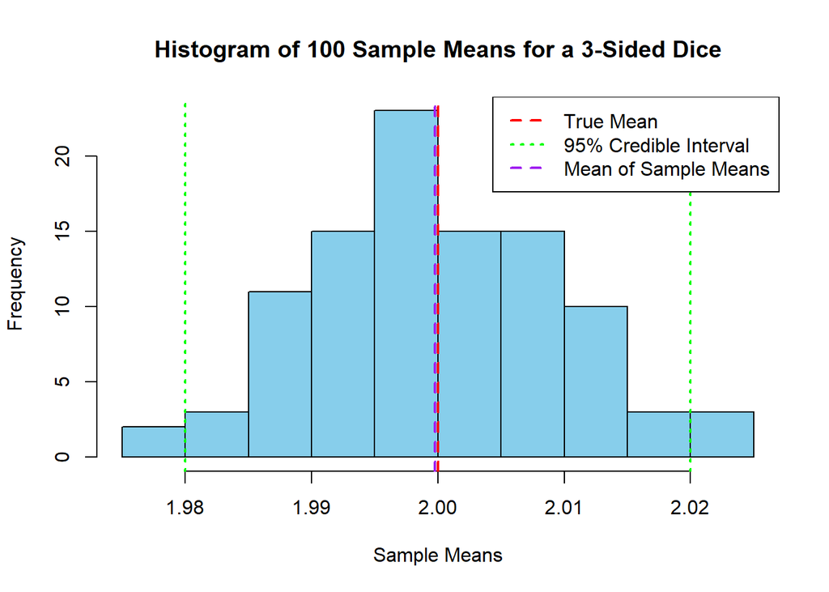

```r
# Plot the histogram
hist(dat_1$y_bar,
     col = "skyblue",
     main = "Histogram of 100 Sample Means for a 3-Sided Dice",
     xlab = "Sample Means",
     ylab = "Frequency",
     breaks = 16,
     border = "black"
)
abline(v = true_mean_1, col = "red", lwd = 2, lty = 2)  # Mean line (red, dashed)
abline(v = lower_bound_1, col = "green", lwd = 2, lty = 3)  # Lower bound (green, dotted)
abline(v = upper_bound_1, col = "green", lwd = 2, lty = 3)  # Upper bound (green, dotted)
abline(v = mean(dat_1$y_bar), col = "purple", lwd = 2, lty = 2)
legend("topright",
       legend = c("True Mean", "95% Credible Interval", "Mean of Sample Means"),
       col = c("red", "green", "purple"),
       lty = c(2, 3),
       lwd = 2,
       bty = "o"
)
```

```r
# 6-sided dice
# Simulate rolling a die
die_roll <- function(faces = k){
  sample(1 : faces, size = n, replace = TRUE)
}
# Random seed
set.seed(777)

# Number of faces on the die
k <- 6

# Number of samples needed for margin of error of 1% with a 95% confidence level
n <- ceiling(((k-1)*196^2)/((k+1)*3))

# Number of random samples
m <- 100

y_bars <- numeric(m)

# This loop will simulate and store 100 different sample means each of size n
for (i in 1 : m){
  Y_sum <- 0
  for (j in 1 : n){
    Y_sum <- Y_sum + sample(1:k, size = 1, replace = TRUE)
  }
  y_bars[i] <- Y_sum/n
}

# True population mean
true_mean_2 <- 3.5

# 1% of the true mean and the lower and upper bounds
percent_bound_2 <- 0.01 * true_mean_2
lower_bound_2 <- true_mean_2 - percent_bound_2
upper_bound_2 <- true_mean_2 + percent_bound_2

# Prepare data for plotting
dat_2 <- data.frame(y_bar = y_bars)

#Number of samples n
cat(paste0("Number of samples for the sample mean to be within 1% of true sample mean, n = ", n, "\n"))
```

```
## Number of samples for the sample mean to be within 1% of true sample mean, n = 9147
```

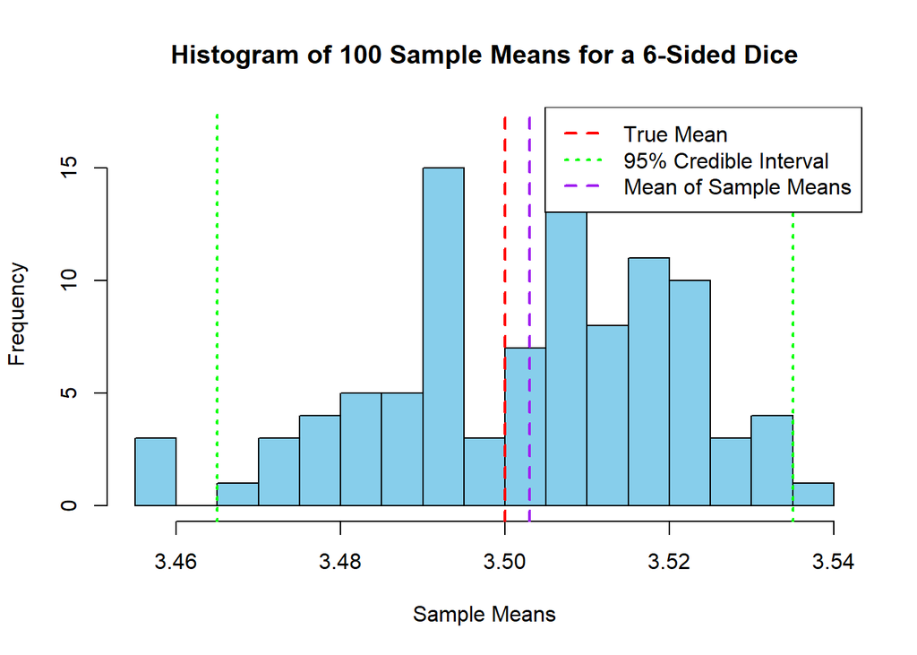

```r
# Plot the histogram
hist(dat_2$y_bar,
     col = "skyblue",
     main = "Histogram of 100 Sample Means for a 6-Sided Dice",
     xlab = "Sample Means",
     ylab = "Frequency",
     breaks = 16,
     border = "black"
)
abline(v = true_mean_2, col = "red", lwd = 2, lty = 2)  # Mean line (red, dashed)
abline(v = lower_bound_2, col = "green", lwd = 2, lty = 3)  # Lower bound (green, dotted)
abline(v = upper_bound_2, col = "green", lwd = 2, lty = 3)  # Upper bound (green, dotted)
abline(v = mean(dat_2$y_bar), col = "purple", lwd = 2, lty = 2)
legend("topright",
       legend = c("True Mean", "95% Credible Interval", "Mean of Sample Means"),
       col = c("red", "green", "purple"),
       lty = c(2, 3),
       lwd = 2,
       bty = "o"
)
```

## Analysis of the CLT in our experiment

As stated by the CLT, if we were to repeatedly take samples of the same size from the population and calculate the sample mean for each, approximately 95% of those sample means would fall within 1% (above or below) of the true population mean. We can see from the two tests above that if we take 6403 and 9147 samples from a random population of 3-sided and 6-sided die rolls respectively, 95% of these samples will be within 1% percent of the true mean. From the histograms above we can count the amount of sample means that are outside of the bounds, but the sample means are always less or equal to 5. Since the histogram represents 100 sample means, at least 95% of them should fall within our bounds and that is exactly what we observe.

$$\\$$
$$\\$$

# Bayesian Analysis

## Problem setup

Let $\theta_i=$ The probability of rolling a $i$. Then with a equally weighted die $\theta_1=\theta_2=\dots =\theta_k=\theta$. In general we can set the problem up as follows
$$g^*(\theta|\bar{Y}_{n,k}) =
\frac{L(\bar{Y}_{n,k}|\theta)\cdot
g(\theta)}{m(\bar{Y}_{n,k})}$$

First, the prior, $g(\theta)$, will represent our knowledge about $\theta$ for a certain type of dice. Since we are assuming the dice is equally weighed, $\theta=\theta_1=\theta_2=\dots=\theta_k$. The Symmetric Dirichlet assumes that all outcomes are equally likely, making it a perfect fit for scenarios like rolling multiple fair die where there isn’t any prior knowledge favoring one outcome over another. The Symmetric Dirichlet distribution is a common special case of the Dirichlet distribution where $\alpha_1=\alpha_2=\dots=\alpha_k=\alpha$. The density function is given by
$$f(\theta_1, \ldots, \theta_K; \alpha) =
\frac{\Gamma(\alpha K)}{\left(\Gamma(\alpha)\right)^K} \prod_{i=1}^{K}
\theta_i^{\alpha - 1}$$
Since $\alpha_1=\alpha_2=\dots=\alpha_k=\alpha$, $\alpha_0=\sum \alpha_i =\alpha+\alpha+\dots+\alpha=k\cdot \alpha$. By using the mean of the Dirichlet distribution we can calculate $E[\theta_i] = \frac{\alpha_i}{\alpha_0}=\frac{\alpha}{k\alpha}=\frac{1}{k}$, which is the same as the prior belief. In reality, this is a strong belief. An example of this would be in a coin flip, where the chance of getting heads or tails is 50%, or in other words $\frac{1}{2}$. The value, $\alpha$, represents how strongly we believe each probability $\theta_i$ should be concentrated around a certain value, which in our case is $\frac{1}{k}$. Therefore, we shall choose $\alpha \gg 1$.

Note that $\theta_i$ represents the probability of rolling the $i^{th}$ face of the die. According to the marginal density of the Dirichlet distribution, $\theta_i \sim Beta(\alpha_i,\alpha_0-\alpha_i)$, but since we know that $\alpha_i=\alpha$ and $\alpha_0=k\cdot \alpha$ $\theta_i \sim Beta(\alpha,(k-1)\alpha)$. The marginal density of $\theta_i$, $f(\theta_i)$, describes how likely different values of $\theta_i$ are, and as we can see from above all the variables are distributed the same. Thus, we can say that $\theta_1=\cdots=\theta_k=\theta$ and then we can conclude that $\theta \sim Beta(\alpha,(k-1)\alpha)$. As a result,
$$f(\theta) =
\frac{1}{B(\alpha,(k-1)\alpha)}\cdot\theta^{\alpha-1}\cdot(1-\theta)^{(k-1)\alpha}$$
$$E[\theta]=\frac{\alpha}{\alpha+k\alpha-\alpha}=\frac{1}{k}$$

Next, the likelihood asks what the probability of the data is given that our hypothesis is true. So in this case it would be asking the probability of $\bar{Y}_n=\bar{y}_n$ given $\theta$. Thus, we can rewrite it as $L(\bar{Y}_n|\theta)$. We can model the likelihood using the distribution of sums of dice rolls, which is derived and discussed here, https://www.analyticscheck.net/posts/sums-dice-rolls. Consider the following equation for the sum of $Y_i$’s,

$$\begin{eqnarray*}
S_{n,k} &= &Y_1+Y_2+\dots+Y_k=\sum{Y_i}\\
\bar{Y}_{n,k} &=
&\frac{Y_1+Y_2+\dots+Y_k}{n}=\frac{\sum{Y_i}}{n} = \frac{1}{n}\cdot
S_{n,k}
\end{eqnarray*}$$

The distribution of sums of dice rolls is given by
$$Pr(S_{n,k}=s) = \frac{1}{k^n}
\sum_{l=0}^{\lfloor \frac{s-n}{ k} \rfloor} (-1)^l \binom{n}{l}
\binom{s-kl-1}{n-1}$$

We can use this to find $Pr(\bar{Y}_{n,k}=y)$,

$$\begin{eqnarray*}
Pr(\bar{Y}_{n,k}=y) &= &Pr(\frac{1}{n}\cdot
S_{n,k}=y)=Pr(S_{n,k}=n\cdot y)\\
Pr(S_{n,k}=n\cdot y) &= &\frac{1}{k^n} \sum_{l=0}^{\lfloor
\frac{n(y-1)}{ k} \rfloor} (-1)^l \binom{n}{l} \binom{n\cdot
y-kl-1}{n-1} \\
Pr(\bar{Y}_{n,k}=y|\theta=\frac{1}{k}) &= &\theta^n
\sum_{l=0}^{\lfloor \theta{n(y-1)} \rfloor} (-1)^l \binom{n}{l}
\binom{n\cdot y-\frac{l}{\theta}-1}{n-1}
\end{eqnarray*}$$

Finally, the marginal likelihood is given by the following function, $m(\bar{Y}_{n,k}) = \int_{-\infty}^{\infty} f(\bar{Y}_{n,k},\theta) \, d\theta$, where $f(\bar{Y}_{n,k},\theta) = L(\bar{Y}_n|\theta) \cdot g(\theta)$. This is where things start getting complicated quickly. We can recall that our likelihood function has a combinatorial formula dependent on $\theta$, and the upper bound of the summation also depends on $\theta$, therefore finding an empirical solution to this equation is almost impossible. Numerical techniques can be used to find approximations for this integral in certain cases, but as you will see in the following section, using Approximate Bayesian Computation can enable us to approximate the posterior for our Bayesian analysis.

## Approximate Bayesian Computation

The Approximate Bayesian Computation (ABC) is used to estimate the posterior when the likelihood and marginal likelihood are too difficult to compute. In our case, the likelihood has a dependence on $\theta$ that complicates our marginal likelihood function, thus we will use ABC to estimate the posterior. First, the prior, $g(\theta)$, has to be simulated. We will be using the Beta distribution which comes from the Dirichlet distribution as explained above. Recall that we want to choose choose $\alpha \gg 1$, so let $\alpha = 10$. We will simulate the prior for a 3-sided dice first and then for a 6-sided dice.

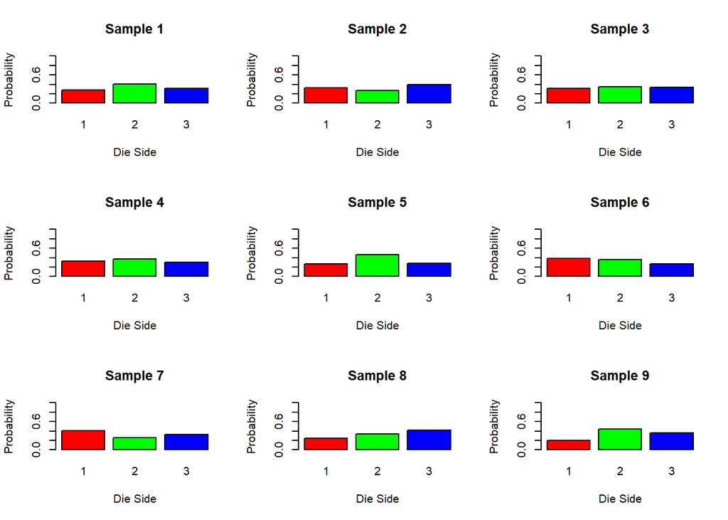

```r
k <- 3                  # Number of sides on the die
alpha <- rep(10, k)     # Shape parameter for Beta distribution
number_samples <- 6403  # The number of samples was chosen to match the sample size in our Frequentist analysis

# Generate random samples from the Beta distribution for each die side. Each side will have a separate Beta distribution
samples <- matrix(NA, number_samples, k)
for (i in 1:k) {
  samples[, i] <- rbeta(number_samples, alpha[i], alpha[i])
}

# Normalize each sample so that it sums to 1. In the output, this means that each row will sum to 1
samples <- t(apply(samples, 1, function(x) x / sum(x)))

# This code is to create bar plots for a number of samples. Arbitrarily, 9 samples were chosen.
number_samples_to_plot <- 9
par(mfrow = c(3, 3))
for (i in 1:number_samples_to_plot) {
  barplot(samples[i, ],
          main = paste("Sample", i),
          names.arg = 1:k,
          ylim = c(0, 1),
          col = rainbow(k),
          ylab = "Probability",
          xlab = "Die Side")
}
```

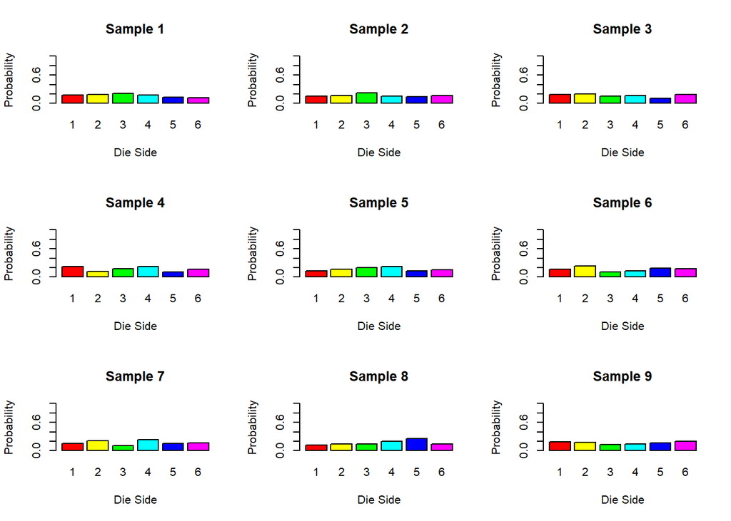

```r
k_2 <- 6                   # Number of sides on the die
alpha_2 <- rep(10, k_2)    # Shape parameter for Beta distribution
number_samples_2 <- 9147   # The number of samples was chosen to match the sample size in our Frequentist analysis

# Generate random samples from the Beta distribution for each die side. Each side will have a separate Beta distribution
samples_2 <- matrix(NA, number_samples_2, k_2)
for (i_2 in 1:k_2) {
  samples_2[, i_2] <- rbeta(number_samples_2, alpha_2[i_2], alpha_2[i_2])
}

# Normalize each sample so that it sums to 1. In the output, this means that each row will sum to 1
samples_2 <- t(apply(samples_2, 1, function(x) x / sum(x)))

# This code is to create bar plots for a number of samples. Arbitrarily, 9 samples were once again chosen
number_samples_to_plot_2 <- 9
par(mfrow = c(3, 3))
for (i_2 in 1:number_samples_to_plot_2) {
  barplot(samples_2[i_2, ],
          main = paste("Sample", i_2),
          names.arg = 1:k_2,
          ylim = c(0, 1),
          col = rainbow(k_2),
          ylab = "Probability",
          xlab = "Die Side")
}
```

Next, the ABC is performed to estimate the posterior, $g^*\left(\theta | \bar{Y}_{n,k} \right)$. The procedure involves simulating data from the prior distribution using different $\theta$ values. Next, a distance metric is defined to compare the simulated data $(D')$ with the observed data $(D)$. A threshold ε is then set. If the distance between $D'$ and $D$ is less than $\varepsilon$, then the parameter $\theta$ is accepted. By collecting all accepted parameter values, we can construct an approximation of the posterior distribution. Mathematically, this looks like $p(D', D) \le \varepsilon$, where $p(D', D)$ is the distance metric. More on this topic and the choice of the Euclidean distance for the distance function can be found here; https://bayesiancomputationbook.com/markdown/chp_08.html. The value of $\varepsilon$ is set to 0.05, however a lower value of $\varepsilon$ would result in less accepted samples and a higher value of $\varepsilon$ would result in more accepted samples. We chose an $\varepsilon$ value of 0.05 as we want the simulated data to closely resemble the true probability of rolling each side. First the ABC is done for the 3-sided die, then the ABC for the 6-sided die follows below.

```r
# As we don't have observed data, we used the expected value of each side of the die, which is 1/3 for each side
observed_data <- c(0.3333333, 0.3333333, 0.3333333)

# We use the Euclidean distance between the sample data and the observed data as our chosen method of obtaining the distance between the simulated data and the observed data
distance_function <- function(samples, observed_data) {
  return(sqrt(sum((samples - observed_data)^2)))
}

# Next, the threshold, ε, is set.
epsilon <- 0.05
accepted_samples <- list()
for (i in 1:number_samples) {
  distance <- distance_function(samples[i, ], observed_data)
  if (distance < epsilon) {
    accepted_samples <- append(accepted_samples, list(samples[i, ]))
  }
}

# Combine all the accepted samples into a matrix for easier manipulation
accepted_samples_matrix <- do.call(rbind, accepted_samples)

# Flatten the matrix into a single vector of all probabilities across all die sides
all_probabilities <- as.vector(accepted_samples_matrix)

# Number of accepted samples
number_accepted_samples <- length(accepted_samples)
print(paste("Number of accepted samples:", number_accepted_samples))
```

```
## [1] "Number of accepted samples: 1306"
```

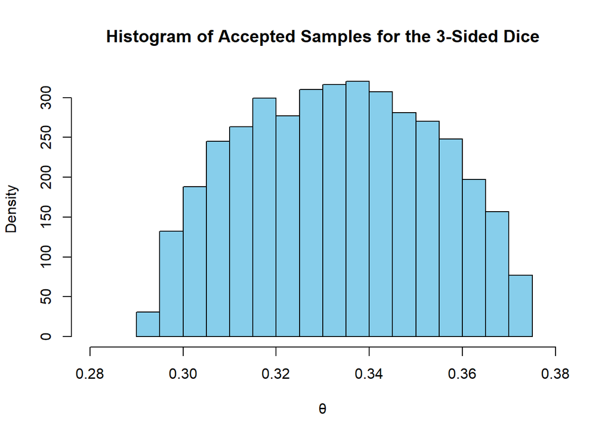

```r
# Histogram for visualization of the accepted samples
hist(all_probabilities,
     main = "Histogram of Accepted Samples for the 3-Sided Dice",
     xlab = "θ",
     ylab = "Density",
     col = "skyblue",
     breaks = 25,
     xlim = c(0.28,0.38))
```

```r
# As we don't have observed data, we used the expected value of each side of the die, which is 1/6 for each side
observed_data_2 <- c(0.1666667, 0.1666667, 0.1666667, 0.1666667, 0.1666667, 0.1666667)

# We use the Euclidean distance between the sample data and the observed data as our chosen method of obtaining the distance between the simulated data and the observed data
distance_function_2 <- function(samples_2, observed_data_2) {
  return(sqrt(sum((samples_2 - observed_data_2)^2)))
}

# Next, the threshold, ε, is set.
epsilon <- 0.05
accepted_samples_2 <- list()
for (i_2 in 1:number_samples_2) {
  distance_2 <- distance_function(samples_2[i_2, ], observed_data_2)
  if (distance_2 < epsilon) {
    accepted_samples_2 <- append(accepted_samples_2, list(samples_2[i_2, ]))
  }
}

# Combine all the accepted samples into a matrix for easier manipulation
accepted_samples_matrix_2 <- do.call(rbind, accepted_samples_2)

# Flatten the matrix into a single vector of all probabilities across all die sides
all_probabilities_2 <- as.vector(accepted_samples_matrix_2)

# Number of accepted samples
number_accepted_samples_2 <- length(accepted_samples_2)
print(paste("Number of accepted samples:", number_accepted_samples_2))
```

```
## [1] "Number of accepted samples: 1155"
```

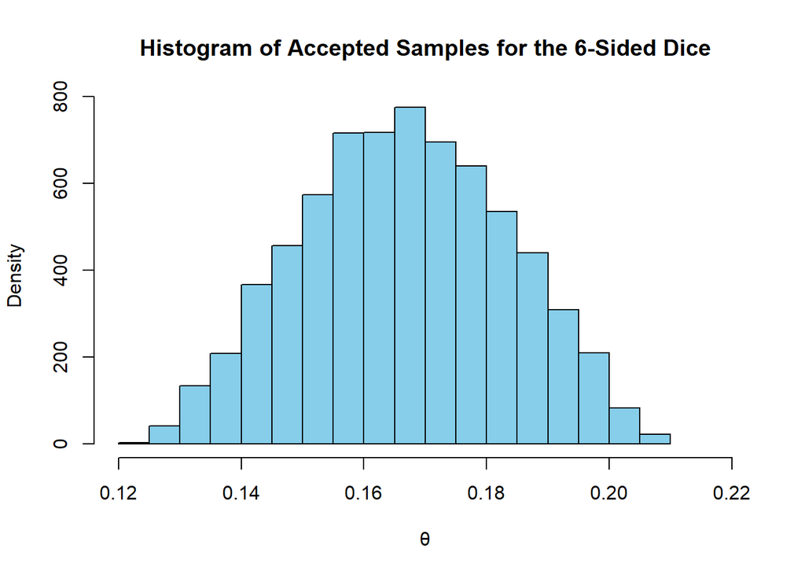

```r
# Histogram for visualization of the accepted samples
hist(all_probabilities_2,
     main = "Histogram of Accepted Samples for the 6-Sided Dice",
     xlab = "θ",
     ylab = "Density",
     col = "skyblue",
     breaks = 30,
     xlim = c(0.12,0.22))
```

We have successfully constructed an approximation for the posterior distribution, $g^*\left( \theta | \bar{Y}_{n,k} \right)$, using the ABC. This will now be used to approximate the mean of a dice roll and we will do that 100 times for both a 3-sided and a 6-sided die in order to investigate how closely our credible interval will be to the true mean of the dice.

## Simulation of a 3-sided and 6-sided die rolling experiment

```r
# Function to simulate a dice roll using the probabilities from samples. Note that this is done because the values simulated earlier where just used for the Beta distribution, rather than being stored.
simulate_Y_dice <- function(samples) {
  simulated_Y <- sample(1:3, 1, prob = samples)
  return(simulated_Y)
}

# Number of simulations
number_simulations <- 100

# List to store means for each simulation
all_means_1 <- numeric(number_simulations)

# Run the simulation 100 times and store values
for (simulation in 1:number_simulations) {
  population_means <- numeric(length(accepted_samples))
  for (i in 1:length(accepted_samples)) {
    samples <- accepted_samples[[i]]
    value_3 <- simulate_Y_dice(samples)
    population_means[i] <- value_3
  }
  all_means_1[simulation] <- mean(population_means)
}

# Credible interval
credible_interval_means_1 <- quantile(all_means_1, c(0.025, 0.975))

# Print results
cat("Overall Mean of the Sample Means:", mean(all_means_1), "\n")
```

```
## Overall Mean of the Sample Means: 1.998254
```

```r
cat("95% Credible Interval of Means:", credible_interval_means_1, "\n")
```

```
## 95% Credible Interval of Means: 1.961677 2.039453
```

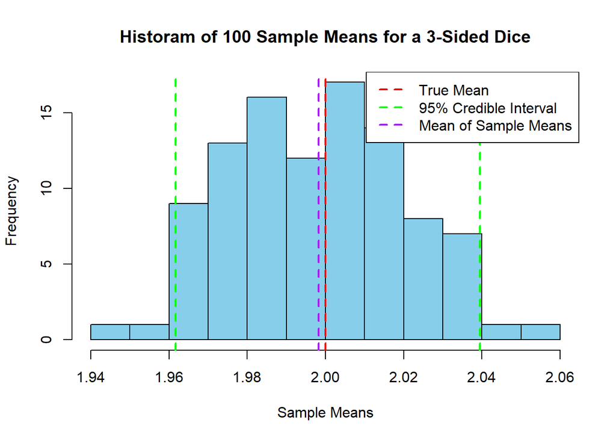

```r
# Plot the histogram of the accepted samples, with the credible interval, mean and legend
hist(all_means_1,
     col = "skyblue",
     main = "Historam of 100 Sample Means for a 3-Sided Dice",
     xlab = "Sample Means",
     ylab = "Frequency",
     breaks = 10)

abline(v = 2, col = "red", lwd = 2, lty = 2)
abline(v = credible_interval_means_1[1], col = "green", lwd = 2, lty = 2)
abline(v = credible_interval_means_1[2], col = "green", lwd = 2, lty = 2)
abline(v = mean(all_means_1), col = "purple", lwd = 2, lty = 2)

legend("topright",
       legend = c("True Mean", "95% Credible Interval", "Mean of Sample Means"),
       col = c("red", "green", "purple"),
       lty = c(2, 2, 2),
       lwd = 2)
```

```r
# Function to simulate a dice roll using the probabilities from samples. Note that this is done because the values simulated earlier where just used for the Beta distribution, rather than being stored.
simulate_Y_dice_2 <- function(samples_2) {
  simulated_Y_2 <- sample(1:6, 1, prob = samples_2)
  return(simulated_Y_2)
}

# Number of simulations
number_simulations_2 <- 100

# List to store means for each simulation
all_means_2 <- numeric(number_simulations_2)

# Run the simulation 100 times and store values
for (simulation in 1:number_simulations_2) {
  population_means_2 <- numeric(length(accepted_samples_2))
  for (i_2 in 1:length(accepted_samples_2)) {
    samples_2 <- accepted_samples_2[[i_2]]
    value_4 <- simulate_Y_dice_2(samples_2)
    population_means_2[i_2] <- value_4
  }
  all_means_2[simulation] <- mean(population_means_2)
}

# Credible interval
credible_interval_means_2 <- quantile(all_means_2, c(0.025, 0.975))

# Print results
cat("Overall Mean of the Sample Means:", mean(all_means_2), "\n")
```

```
## Overall Mean of the Sample Means: 3.517203
```

```r
cat("95% Credible Interval of Means:", credible_interval_means_2, "\n")
```

```
## 95% Credible Interval of Means: 3.408074 3.61526
```

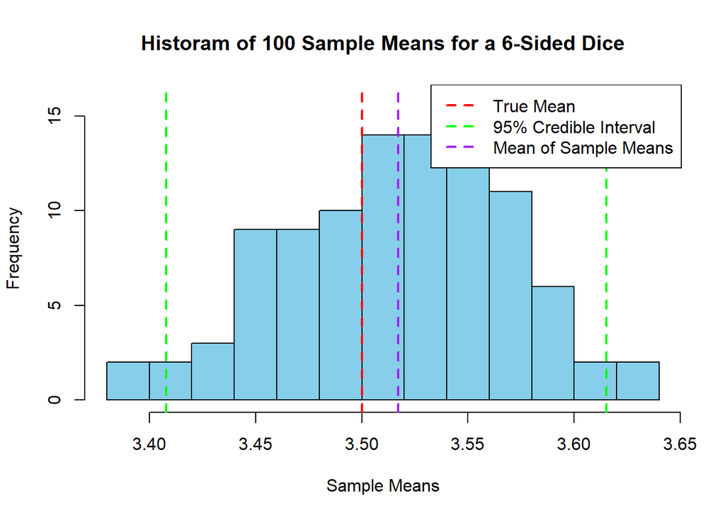

```r
# Plot the histogram of the accepted samples, with the credible interval, mean and legend
hist(all_means_2,
     col = "skyblue",
     main = "Historam of 100 Sample Means for a 6-Sided Dice",
     xlab = "Sample Means",
     ylab = "Frequency",
     breaks = 10)

abline(v = 3.5, col = "red", lwd = 2, lty = 2)
abline(v = credible_interval_means_2[1], col = "green", lwd = 2, lty = 2)
abline(v = credible_interval_means_2[2], col = "green", lwd = 2, lty = 2)
abline(v = mean(all_means_2), col = "purple", lwd = 2, lty = 2)
legend("topright",
       legend = c("True Mean", "95% Credible Interval", "Mean of Sample Means"),
       col = c("red", "green", "purple"),
       lty = c(2, 2, 2),
       lwd = 2)
```

$$\\$$
$$\\$$

# Final Analysis and Summary

## Summary and Analysis

Before we compare the Frequentist and Bayesian methods we will create a summarized plot to visualize our findings.

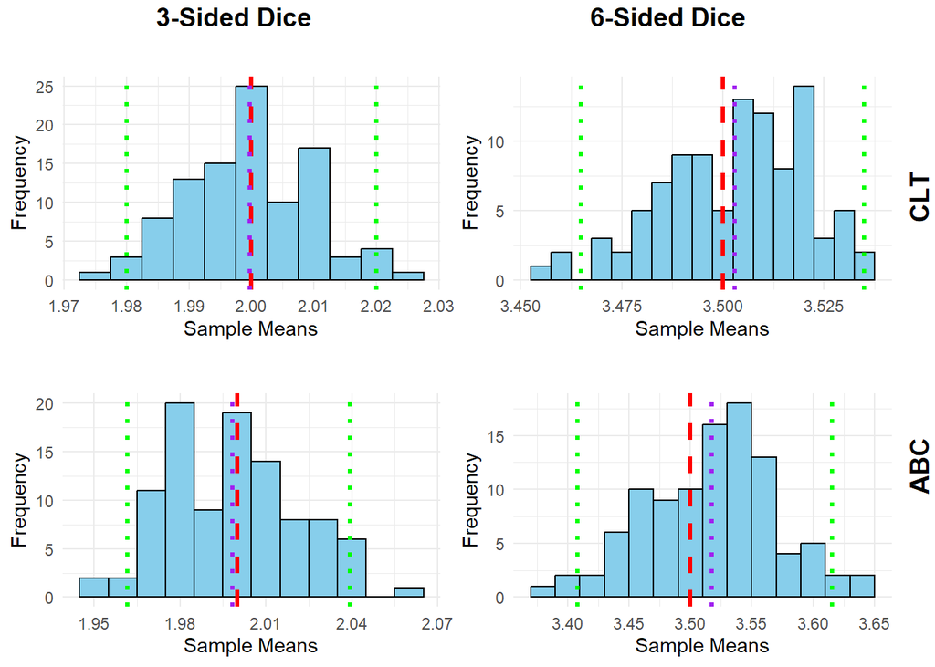

## Conclusion

This study examined the accuracy of estimating the population mean for dice rolls using two different statistical approaches: the Frequentist approach via the Central Limit Theorem (CLT) and the Bayesian approach via Approximate Bayesian Computation (ABC). The CLT demonstrated that for sufficiently large sample sizes (6403 rolls for 3-sided dice and 9147 rolls for 6-sided dice), 95% of the sample means fell within 1% of the true mean. This confirms that the CLT guarantees the sample mean approaches a normal distribution with the mean approaching the true mean as the sample size increases. The resulting confidence intervals were narrow, indicating high precision.

In conclusion, both approaches successfully estimate the true mean of dice rolls, but the CLT proved to be more useful and easier to perform. The mean of the CLT experiment is closer to the true mean and provides more accurate intervals compared to the ABC experiment. Although this project allowed for a interesting exploration into the ABC method, we have to conclude that our original hypothesis is incorrect, thus the CLT proves to be more useful in approximating the true mean from the sample mean compared to the ABC method in our dice rolling experiment. This comes as the CLT is generally better for larger data sets, and better for models without a strong prior belief. Finally, this project provided a great insight into the overall discussion of the Frequentist vs Bayesian approaches, and introduced some engaging concepts such as the ABC.